### Task 4: Imputing missing values

A number of days/intervals have missing values (coded as NA). The presence of missing days may introduce bias into some calculations or summaries of the data.

**1. Calculate and report the total number of missing values in the dataset (i.e. the total number of rows with NAs)**

```r
cat(sprintf("\nTotal number of rows with NAs: %1.0f \n", sum(is.na(data$steps))))
```

```
##
## Total number of rows with NAs: 2304
```

**2. Devise a strategy for filling in all of the missing values in the dataset** Strategy followed is to replace NAs with the mean value for that activity obtained from the data set which ignored NAs.

**3. New dataset that is equal to the original dataset but with the missing data filled in.**

```r
dataNew <- merge(data, stepsInterval, by= "interval")
dataNew$stepsIncNa <- with(dataNew, ifelse(!is.na(steps.x),steps.x, steps.y))
```

**4 Analysis the total number of steps taken each day**

*Using a Histogram*

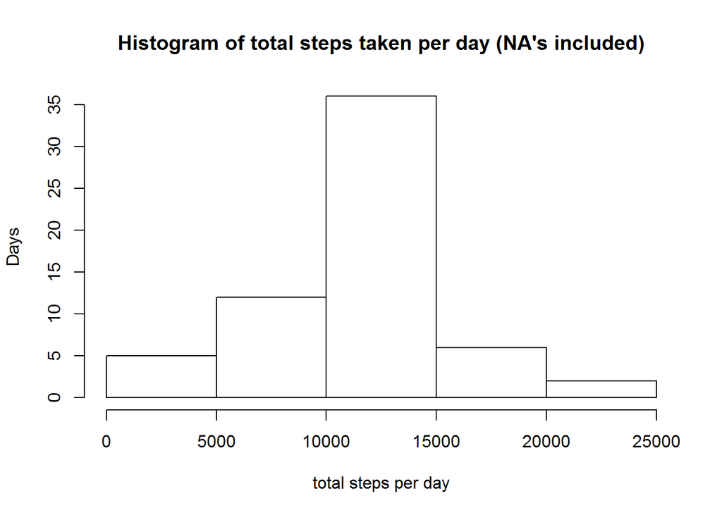

```r
stepsTotalIncNa <- aggregate(stepsIncNa ~ date, data = dataNew, sum, na.rm = TRUE)
hist(stepsTotalIncNa$steps, xlab = "total steps per day", ylab = "Days",
    main = paste("Histogram of total steps taken per day (NA's included)"))
```

*By calculating and reporting the mean and median total number of steps taken per day.*

```r
cat(sprintf("Mean number of steps taken each day (NAs included): %1.0f \n",
mean(stepsTotalIncNa$steps)))
```

```
## Mean number of steps taken each day (NAs included): 10766
```

```r
cat(sprintf("Median number of steps taken each day (NAs included): %1.0f\n",
median(stepsTotalIncNa$steps)))
```

```
## Median number of steps taken each day (NAs included): 10766
```

### Task 4: analysis for differences in activity patterns between weekdays and weekends.

**1. Create a new factor variable in the dataset indicating if it is a weekend or weekday.**

```r
dataNew$day <- weekdays(as.Date(dataNew$date))
dataNew$weekend <- as.factor(with(dataNew, ifelse(day == "Saturday","weekend",
ifelse(day == "Sunday","weekend","weekday"))))
```

Create a panel plot containing a time series plot of the 5-minute interval (x-axis) and the average number of steps taken, averaged across all weekday days or weekend days (y-axis)

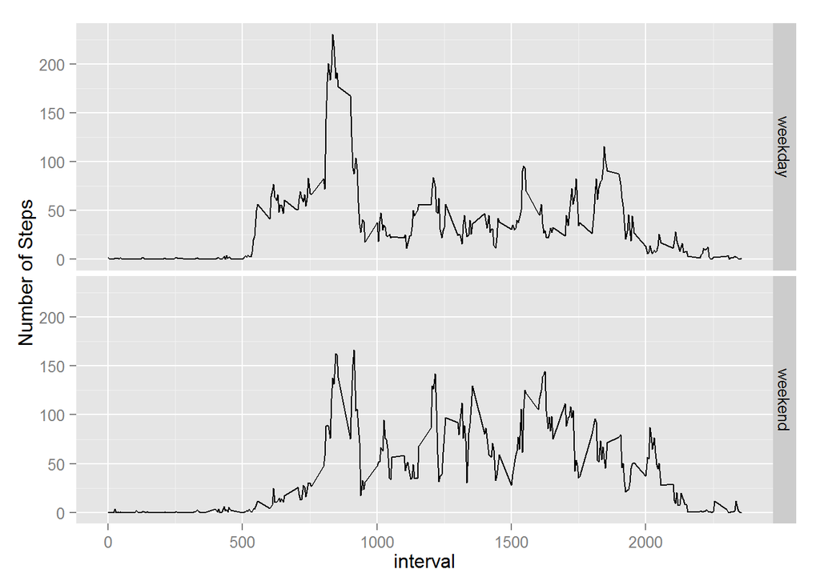

```r
library(ggplot2)
stepsTotalIncNa <- aggregate(stepsIncNa ~ interval + weekend, data = dataNew, mean, na.rm = TRUE)
p <- ggplot(stepsTotalIncNa, aes(x = interval, y=stepsIncNa)) + geom_line()
p + facet_grid(weekend~.) + ylab("Number of Steps")
```